# Fitness_analysis_LHPS

Cecilia Trivellin

2023-12-29

## Analysis of the genetic markers of microbial robustness

This script is used to analyse fitness data of Saccharomyces cerevisiae strains. Each strain carries a deletion that should confer either lower or higher robustness. The genes that have been deleted are the following:

1. CEN.PK113-7D (ΔQDR1)
2. CEN.PK113-7D (ΔGBP2)
3. CEN.PK113-7D (ΔMRP13)
4. CEN.PK113-7D (ΔWWM)
5. CEN.PK113-7D (ΔHCM1)
6. CEN.PK113-7D (ΔOCA4)
7. CEN.PK113-7D (ΔRPS14A)
8. CEN.PK113-7D (ΔSMA2)
9. CEN.PK113-7D (ΔMSH3)
10. CEN.PK113-7D (ΔRPS14B)
11. CEN.PK113-7D (ΔMET28)
12. CEN.PK113-7D (ΔBCH1)
13. CEN.PK113-7D (ΔTIR3)
14. CEN.PK113-7D (ΔHLJ1) Plus control strains:
15. CEN.PK113-7D parental
16. Ethanol Red

The genes chosen above followed the analysis made with the R_mutants.Rmd script.

The strains above were grown in three different perturbation spaces. The second one contained the following perturbations:

1. Delft
2. Delft_80NaCl
3. Delft_50etoh
4. Delft_25NaCl
5. Delft-05VM
6. Delft_100glu
7. Delft_100etoh
8. Delft_5glu
9. Delft_NB
10. Delft_10LA
11. Delft_HMF1
12. Delft_FA2
13. Delft_pH3
14. Delft_AA2
15. SCH100 (synthetic corn hydrolisate)
16. SSH20 (synthetic spruce hydrolisate 20%)

Corresponding to different perturbations present in the lignocellulose biomass fermentation into ethanol. For precise compositions check publication material and methods.

### Loading libraries

```r
library(readxl)
library(tidyverse)
library(deSolve)
library(growthrates)
library(bbplot)
library(ggpubr)
library(Cairo)
```

### Importing data and summary

```r
summary <- read_excel("~/Library/CloudStorage/OneDrive-Chalmers/PhD/Experimental_Data/Robusntess application on existing dataset/Fitness assays/media_composition_LHFEPP.xlsx",
    sheet = "summary")

head(summary)
```

```
## # A tibble: 6 × 3
##   well  media      replicate
##   <chr> <chr>          <dbl>
## 1 A1    Delft              1
## 2 A2    Delft              2
## 3 A3    Delft              3
## 4 A4    Delft-05VM         1
## 5 A5    Delft-05VM         2
## 6 A6    Delft-05VM         3
```

```r
strain <- read_excel("~/Library/CloudStorage/OneDrive-Chalmers/PhD/Experimental_Data/Robusntess application on existing dataset/Fitness assays/media_composition_LHFEPP.xlsx",
    sheet = "strain")

head(strain)
```

```
## # A tibble: 6 × 9
##   well  plate1 plate2 plate3 plate4 plate5 plate6 plate7 plate8
##   <chr> <chr>  <chr>  <chr>  <chr>  <chr>  <chr>  <chr>  <chr>
## 1 A1    qdr1   mrp13  hcm1   rps14a msh3   bch1   hlj1   tir3
## 2 A2    qdr1   mrp13  hcm1   rps14a msh3   bch1   hlj1   tir3
## 3 A3    qdr1   mrp13  hcm1   rps14a msh3   bch1   hlj1   tir3
## 4 A4    qdr1   mrp13  hcm1   rps14a msh3   bch1   hlj1   tir3
## 5 A5    qdr1   mrp13  hcm1   rps14a msh3   bch1   hlj1   tir3
## 6 A6    qdr1   mrp13  hcm1   rps14a msh3   bch1   hlj1   tir3
```

```r
QDR1_GBP2 <- read_excel("~/Library/CloudStorage/OneDrive-Chalmers/PhD/Experimental_Data/Robusntess application on existing dataset/Fitness assays/prj_rob_genes_LHPS_2/LHPS_part1.xlsx",
    sheet = "QDR1-GBP2_GV") %>%
    mutate(timeh = `time`/60) %>%
    select(-`time`)%>%
    gather("well", "value", -timeh)

MRP13_WWM1 <- read_excel("~/Library/CloudStorage/OneDrive-Chalmers/PhD/Experimental_Data/Robusntess application on existing dataset/Fitness assays/prj_rob_genes_LHPS_2/LHPS_part1.xlsx",
    sheet = "MRP13-WWM1_GV")%>%
    mutate(timeh = `time`/60) %>%
    select(-`time`)%>%
    gather("well", "value", -timeh)


HCM1_OCA4 <- read_excel("~/Library/CloudStorage/OneDrive-Chalmers/PhD/Experimental_Data/Robusntess application on existing dataset/Fitness assays/prj_rob_genes_LHPS_2/LHPS_part1.xlsx",
    sheet = "HCM1-OCA4_GV")%>%
    mutate(timeh = `time`/60) %>%
    select(-`time`)%>%
    gather("well", "value", -timeh)

RPS14A_SMA2 <- read_excel("~/Library/CloudStorage/OneDrive-Chalmers/PhD/Experimental_Data/Robusntess application on existing dataset/Fitness assays/prj_rob_genes_LHPS_2/LHPS_part2.xlsx",
    sheet = "RPS14A-SMA2_GV")%>%
    mutate(timeh = `time`/60) %>%
    select(-`time`)%>%
    gather("well", "value", -timeh)

MSH3_RPS14B <- read_excel("~/Library/CloudStorage/OneDrive-Chalmers/PhD/Experimental_Data/Robusntess application on existing dataset/Fitness assays/prj_rob_genes_LHPS_2/LHPS_part2.xlsx",
    sheet = "MSH3-RPS14B_GV")%>%
    mutate(timeh = `time`/60) %>%
    select(-`time`)%>%
    gather("well", "value", -timeh)

BCH1_MET28 <- read_excel("~/Library/CloudStorage/OneDrive-Chalmers/PhD/Experimental_Data/Robusntess application on existing dataset/Fitness assays/prj_rob_genes_LHPS_2/LHPS_part2.xlsx",
    sheet = "BCH1-MET28_GV")%>%
    mutate(timeh = `time`/60) %>%
    select(-`time`)%>%
    gather("well", "value", -timeh)

HLJ1_ETRED <- read_excel("~/Library/CloudStorage/OneDrive-Chalmers/PhD/Experimental_Data/Robusntess application on existing dataset/Fitness assays/prj_rob_genes_LHPS_2/LHPS_part3.xlsx",
    sheet = "HLJ1-ETRED_GV")%>%
    mutate(timeh = `time`/60) %>%
    select(-`time`)%>%
    gather("well", "value", -timeh)

TIR3_CENPK <- read_excel("~/Library/CloudStorage/OneDrive-Chalmers/PhD/Experimental_Data/Robusntess application on existing dataset/Fitness assays/prj_rob_genes_LHPS_2/LHPS_part3.xlsx",
    sheet = "TIR3-CENPK_GV") %>%
    mutate(timeh = `time`/60) %>%
    select(-`time`)%>%
    gather("well", "value", -timeh)

head(TIR3_CENPK)
```

```
## # A tibble: 6 × 3
##   timeh well  value
##   <dbl> <chr> <dbl>
## 1  0    A1     9.38
## 2  0.5  A1     9.84
## 3  1    A1    10.1
## 4  1.5  A1    10.5
## 5  2    A1    11.1
## 6  2.52 A1    11.7
```

### Preprocessing growth data

```r
# Define a function to merge and preprocess growth data
ss_df <- function(df1, df2, df3, coln) {
  tmp <- inner_join(df1, df2, by="well")
  merge(tmp, df3[, c("well", coln)], by="well",all.x=TRUE)%>%
  group_by(media, timeh) %>%
  mutate(log_value=log(value)) %>%
  mutate(mean=mean(log_value)) %>%
  mutate(stdev=sd(log_value))
  # filter(replicate == 1)
}

# Apply ss_df function to preprocess growth data for all strains
QDR1_GBP2 <- ss_df(QDR1_GBP2, summary, strain, "plate1") %>%
  rename(strain=plate1)
MRP13_WWM1 <- ss_df(MRP13_WWM1, summary, strain, "plate2")%>%
  rename(strain=plate2)
HCM1_OCA4 <- ss_df(HCM1_OCA4, summary, strain, "plate3")%>%
  rename(strain=plate3)
RPS14A_SMA2 <- ss_df(RPS14A_SMA2, summary, strain, "plate4")%>%
  rename(strain=plate4)
MSH3_RPS14B <- ss_df(MSH3_RPS14B, summary, strain, "plate5")%>%
  rename(strain=plate5)
BCH1_MET28 <- ss_df(BCH1_MET28, summary, strain, "plate6")%>%
  rename(strain=plate6)
HLJ1_ETRED <- ss_df(HLJ1_ETRED, summary, strain, "plate7")%>%
  rename(strain=plate7)
TIR3_CENPK <- ss_df(TIR3_CENPK, summary, strain, "plate8")%>%
  rename(strain=plate8)

# Combine the preprocessed data for all strains into a single dataframe
df <- QDR1_GBP2 %>%
  rbind(MRP13_WWM1) %>%
  rbind(HCM1_OCA4) %>%
  rbind(RPS14A_SMA2)%>%
  rbind(MSH3_RPS14B)%>%
  rbind(BCH1_MET28) %>%
  rbind(HLJ1_ETRED) %>%
  rbind(TIR3_CENPK)

head(df)
```

```
## # A tibble: 6 × 9
## # Groups:   media, timeh [6]
##   well  timeh value media replicate strain log_value  mean  stdev
##   <chr> <dbl> <dbl> <chr>     <dbl> <chr>      <dbl> <dbl>  <dbl>
## 1 A1      0    10.6 Delft         1 qdr1        2.36  2.38 0.0685
## 2 A1      0.5  10.9 Delft         1 qdr1        2.39  2.42 0.0622
## 3 A1      1    11.3 Delft         1 qdr1        2.42  2.46 0.0696
## 4 A1      1.5  11.8 Delft         1 qdr1        2.47  2.50 0.0691
## 5 A1      2    12.8 Delft         1 qdr1        2.55  2.59 0.0743
## 6 A1      2.5  13.4 Delft         1 qdr1        2.60  2.63 0.0798
```

```r
#saveRDS(df, file = "LHPS.rds")
```

### Growth curves analysis and plots

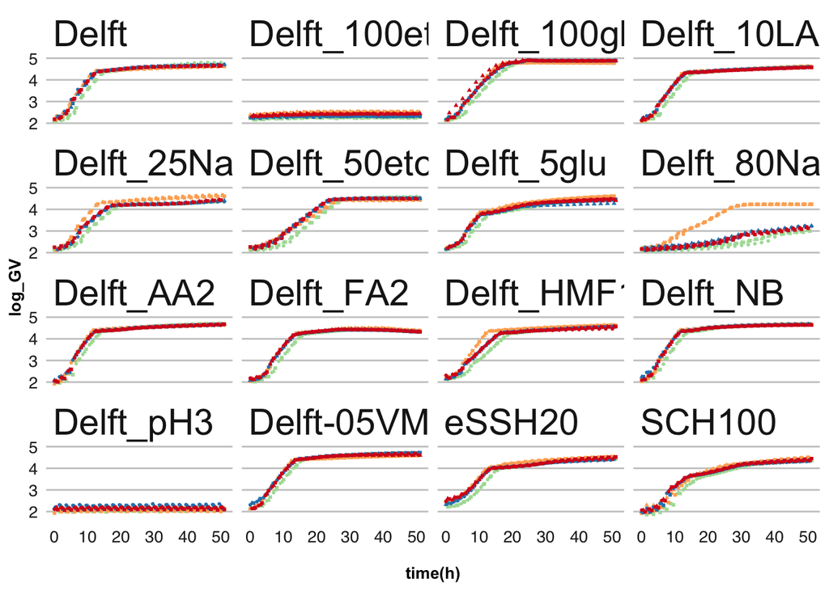

```r
#names of the strains: "qdr1","gbp2","mrp13","wwm1","hcm1","oca4","rps14a","sma2","msh3","rps14b","bch1", "met28","hlj1","EthanolRed", "tir3","CEN.PK113-7D"

# Convert 'replicate' to character type
df <- df %>%
  mutate(replicate= as.character(replicate))

# plot the growth curves
ggplot() +
  geom_point(data = subset(df, strain == c("hlj1","EthanolRed", "tir3","CEN.PK113-7D")), size = 0.7, aes(y=log_value, x=timeh, colour=strain, shape=replicate)) +
scale_colour_brewer(palette = "Spectral") +
  labs(y = "log_GV", x = "time(h)")+
  facet_wrap(~media)  +
  bbc_style()+
  theme(legend.position = "none",
        text = element_text(size = 10),
        axis.text = element_text(size = 10),
        axis.title = element_text(size = 10, face = "bold"),
        plot.title = element_text(size=7))
```

```r
#ggsave("part3_growtcurves_replicates.pdf",device=cairo_pdf, width = 15, height = 10, path = "~/your_directory/")
```

### Calculation of growth rate and lag phase

```r
df <- na.omit(df)

# Fit spline models for each combination of 'strain', 'media', and 'replicate'

many_spline_fits <- all_splines(value ~ timeh | strain + media + replicate, data = df, spar = 0.7)
#par(mfrow = c(6,6))
#par(mar=c(1,1,1,1))
#plot(many_spline_fits)

#data frame is created with the results coming from all_splines function
results <- results(many_spline_fits)

#the umax of the strains that did not grow is set to 0 based on the growth curves above
results$mumax <- ifelse(results$media == "Delft_100etoh" | results$media == "Delft_pH3", 0 , results$mumax) #none of the strains grew with Delft_100etoh or pH3
#single strains that did not grow in certain conditions
results$mumax <- ifelse((results$media == "Delft_80NaCl" | results$media == "Delft_FA2" | results$media == "SCH100") & results$strain == "met28", 0 , results$mumax)

# now the mumax of remaining strains with r2 <= 0.99 and mumax != 0 is set to NA
results <- results %>%
   mutate(mumax = ifelse(r2 <= 0.99 & mumax != 0, NA, mumax))%>% #first I convert all the mumax values <0.99 to NA as the approximation of the function is not reiable
  select(-`y0`)

head(results)
```

```
##                            strain media replicate     mumax        r2
## bch1:Delft:1                 bch1 Delft         1 0.2335334 0.9939329
## CEN.PK113-7D:Delft:1 CEN.PK113-7D Delft         1 0.2195282 0.9950734
## EthanolRed:Delft:1     EthanolRed Delft         1 0.2278546 0.9951338
## gbp2:Delft:1                 gbp2 Delft         1 0.2133260 0.9976302
## hcm1:Delft:1                 hcm1 Delft         1 0.2203326 0.9965781
## hlj1:Delft:1                 hlj1 Delft         1 0.2168178 0.9954473
```

```r
# Calculate the mean 'mumax' for the "CEN.PK113-7D" strain
mean_mumax_CENPK <- mean(filter(results, strain == "CEN.PK113-7D")$mumax)

results <- results %>%
  mutate(replicate= as.character(replicate)) %>%
  mutate(strain = factor(strain,levels=c("CEN.PK113-7D","EthanolRed","qdr1","met28","mrp13","hcm1","gbp2","rps14a","rps14b","oca4","msh3", "bch1", "wwm1","hlj1", "tir3", "sma2")))

p <- ggplot(data= results,
      aes(x = strain,
          y = mumax, fill = strain)
    ) +
    ylim(0,0.3)+
    geom_violin(width=0.9,alpha = 0.3) +
    geom_boxplot(width=0.1,position=position_dodge(0.9), outlier.shape=NA)+
  stat_summary(fun=mean, geom='point', shape=20, size=3, color="white") +
    scale_fill_manual(values=c("black","black","#922A2B","#922A2B","#922A2B","#E2C140","#E2C140","#E2C140","#E2C140","#E2C140","#E2C140", "#4775A5", "#4775A5", "#4775A5", "#4775A5", "#4775A5")) +
    # facet_grid(cols =vars(Strain), rows = vars(Experiment)) +
  geom_hline(yintercept = mean_mumax_CENPK, linetype = "dashed", color = "black")+
    scale_y_continuous(breaks = round(seq(min(results$mumax), max(results$mumax), by = 0.1),1))+
    bbc_style()+
  stat_compare_means(method = "wilcox.test", label = "p.signif",
                     ref.group = "CEN.PK113-7D", size=8, hide.ns = TRUE)+
  guides(fill="none")+
    theme(strip.text = element_text(face="bold"),
        text = element_text(size = 15),
        axis.text.x = element_text(size = 20, angle=90, vjust = 0.5,hjust = 1))

#ggsave("mumax_distribution_rawdata.pdf", width = 15, height = 10, path = "~/your_directory/")
```

### Robusntess calculations (Trivellin et.al, 2022, Eq3)

```r
# Calculate the mean 'mumax' and standard deviation for each 'strain'

df_mean <- results %>%
  group_by(strain) %>% #calculating mean for each sample in the agar plate
  mutate(mean=mean(mumax,  na.rm=TRUE)) %>%
  mutate(stdev=sd(mumax,  na.rm=TRUE)) %>%
  filter(media == "Delft")
mean_mumax <- mean(df_mean$mean)

# Calculate robustness and normalized robustness for each 'strain'

df_R <- df_mean %>%
  mutate(robustness=-stdev^2/mean, na.rm=TRUE)%>%
  mutate(robustness_n=robustness/mean_mumax, na.rm=TRUE) %>%#calculating normalized robustness with the mean of all strains and all experiments
  group_by(strain) %>%
  mutate(mean_R=mean(robustness_n, na.rm=TRUE)) %>% #mean of the 4 replicates per sample coming from the 4 different plates
  mutate(sem_R=sd(robustness_n)/sqrt(3),na.rm=TRUE) %>% #standard error = standard deviation of the sampling distribution/sqrt n of samples
  filter(replicate == "1")

head(df_R)
```

```
## # A tibble: 6 × 12
## # Groups:   strain [6]
##   strain  media replicate mumax    r2  mean  stdev robustness na.rm robustness_n
##   <fct>   <chr> <chr>     <dbl> <dbl> <dbl>  <dbl>      <dbl> <lgl>        <dbl>
## 1 bch1    Delft 1         0.234 0.994 0.152 0.0713    -0.0335 TRUE        -0.242
## 2 CEN.PK… Delft 1         0.220 0.995 0.151 0.0733    -0.0357 TRUE        -0.258
## 3 Ethano… Delft 1         0.228 0.995 0.161 0.0751    -0.0349 TRUE        -0.252
## 4 gbp2    Delft 1         0.213 0.998 0.137 0.0660    -0.0319 TRUE        -0.231
## 5 hcm1    Delft 1         0.220 0.997 0.149 0.0697    -0.0327 TRUE        -0.236
## 6 hlj1    Delft 1         0.217 0.995 0.145 0.0682    -0.0321 TRUE        -0.232
## # ℹ 2 more variables: mean_R <dbl>, sem_R <dbl>
```

### Plotting robusntess

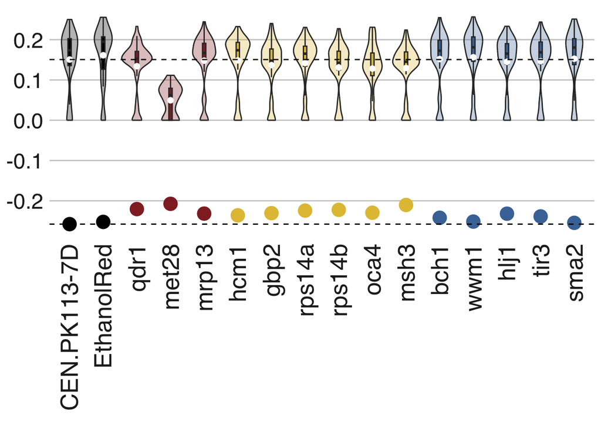

```r
p + geom_point(data=df_R, aes(x=strain, y=robustness_n, color=strain),size=5)+
  ylim(-0.3,0.3)+
  scale_color_manual(values=c("black","black","#922A2B","#922A2B","#922A2B","#E2C140","#E2C140","#E2C140","#E2C140","#E2C140","#E2C140", "#4775A5", "#4775A5", "#4775A5", "#4775A5", "#4775A5")) +
  geom_hline(aes(yintercept = robustness_n),
              data = filter(df_R, strain == "CEN.PK113-7D"),
             linetype = "dashed", color = "black")+
  scale_y_continuous(breaks = round(seq(min(df_R$robustness_n), max(results$mumax), by = 0.1),1))+
  bbc_style()+
  guides(color="none")+
  theme(strip.text = element_text(face="bold"),
        text = element_text(size = 15),
        axis.text.x = element_text(size = 20, angle=90, vjust = 0.5,hjust = 1))
```

```r
#ggsave("FR_LHPS_1.pdf", device=cairo_pdf, width = 15, height = 10, path = "~/your_directory/")
```